# Leverage deployment guardrails to update a SageMaker Inference endpoint using canary traffic shifting

# Contents

- Introduction
- Setup
- Step 1: Create and deploy the pre-trained models
- Step 2: Invoke Endpoint
- Step 3: Create CloudWatch alarms to monitor Endpoint performance
- Step 4: Update Endpoint with deployment configurations- Canary Traffic Shifting
- Cleanup

# Introduction

Deployment guardrails are a set of model deployment options in Amazon SageMaker Inference to update your machine learning models in production. Using the fully managed deployment guardrails, you can control the switch from the current model in production to a new one. Traffic shifting modes, such as canary and linear, give you granular control over the traffic shifting process from your current model to the new one during the course of the update. There are also built-in safeguards such as auto-rollbacks that help you catch issues early and take corrective action before they impact production.

We support blue-green deployment with multiple traffic shifting modes. A traffic shifting mode is a configuration that specifies how endpoint traffic is routed to a new fleet containing your updates. The following traffic shifting modes provide you with different levels of control over the endpoint update process:

- **All-At-Once Traffic Shifting** : shifts all of your endpoint traffic from the blue fleet to the green fleet. Once the traffic has shifted to the green fleet, your pre-specified Amazon CloudWatch alarms begin monitoring the green fleet for a set amount of time (the “baking period”). If no alarms are triggered during the baking period, then the blue fleet is terminated.
- **Canary Traffic Shifting** : lets you shift one small portion of your traffic (a “canary”) to the green fleet and monitor it for a baking period. If the canary succeeds on the green fleet, then the rest of the traffic is shifted from the blue fleet to the green fleet before terminating the blue fleet.
- **Linear Traffic Shifting** : provides even more customization over how many traffic-shifting steps to make and what percentage of traffic to shift for each step. While canary shifting lets you shift traffic in two steps, linear shifting extends this to n number of linearly spaced steps.

The Deployment guardrails for Amazon SageMaker Inference endpoints feature also allows customers to specify conditions/alarms based on Endpoint invocation metrics from CloudWatch to detect model performance regressions and trigger automatic rollback.

In this notebook we'll update endpoint with following deployment configurations:

- Blue/Green update policy with **Canary traffic shifting option**
- Configure CloudWatch alarms to monitor model performance and trigger auto-rollback action.

To demonstrate Canary deployments and the auto-rollback feature, we will update an Endpoint with an incompatible model version and deploy it as a Canary fleet, taking a small percentage of the traffic. Requests sent to this Canary fleet will result in errors, which will be used to trigger a rollback using pre-specified CloudWatch alarms. Finally, we will also demonstrate a success scenario where no alarms are tripped and the update succeeds.

This notebook is organized in 4 steps -

- Step 1 creates the models and Endpoint Configurations required for the 3 scenarios - the baseline, the update containing the incompatible model version and the update containing the correct model version.
- Step 2 invokes the baseline Endpoint prior to the update.
- Step 3 specifies the CloudWatch alarms used to trigger the rollbacks.
- Finally in step 4, we update the endpoint to trigger a rollback and demonstrate a successful update.

# Setup

Ensure that you have an updated version of boto3, which includes the latest SageMaker features:

```python
!pip install -U awscli
!pip install sagemaker
```

Setup some required imports and basic initial variables:

```python
%matplotlib inline

import time
import os
import boto3
import botocore
import re
import json
from datetime import datetime, timedelta, timezone
from sagemaker import get_execution_role, session
from sagemaker.s3 import S3Downloader, S3Uploader

region = boto3.Session().region_name

# You can use a different IAM role with "SageMakerFullAccess" policy for this notebook
role = get_execution_role()
print(f"Execution role: {role}")

sm_session = session.Session(boto3.Session())
sm = boto3.Session().client("sagemaker")
sm_runtime = boto3.Session().client("sagemaker-runtime")

# You can use a different bucket, but make sure the role you chose for this notebook
# has the s3:PutObject permissions. This is the bucket into which the model artifacts will be uploaded
bucket = sm_session.default_bucket()
prefix = "sagemaker/Deployment-Guardrails-Canary"
```

```
Execution role: arn:aws:iam::731623272175:role/LabRole
```

Download the Input files and pre-trained model from S3 bucket

```python
!aws s3 cp s3://sagemaker-us-east-1-731623272175/sagemaker/finalproj-food-linearlearner-nr/output/xgboost-tuningjob-11-17-18-41-013-3ebd184c/output/model.tar.gz model/
!aws s3 cp s3://sagemaker-us-east-1-731623272175/sagemaker/finalproj-food-linearlearner-nr/output/xgboost-tuningjob-11-17-18-41-005-0890e241/output/model2.tar.gz model/
!aws s3 cp s3://sagemaker-us-east-1-731623272175/sagemaker/finalproj-food-linearlearner-nr/validation/marketinganalytics_food_finalprojtest.csv test_data/
!aws s3 cp s3://sagemaker-us-east-1-731623272175/sagemaker/finalproj-food-linearlearner-nr/test/marketinganalytics_food_finalproject.csv test_data/
```

```
download: s3://sagemaker-us-east-1-731623272175/sagemaker/finalproj-food-linearlearner-nr/output/xgboost-tuningjob-11-17-18-41-013-3ebd184c/output/model.tar.gz to model/model.tar.gz
download: s3://sagemaker-us-east-1-731623272175/sagemaker/finalproj-food-linearlearner-nr/output/xgboost-tuningjob-11-17-18-41-005-0890e241/output/model2.tar.gz to model/model2.tar.gz
download: s3://sagemaker-us-east-1-731623272175/sagemaker/finalproj-food-linearlearner-nr/validation/marketinganalytics_food_finalprojtest.csv to test_data/marketinganalytics_food_finalprojtest.csv
download: s3://sagemaker-us-east-1-731623272175/sagemaker/finalproj-food-linearlearner-nr/test/marketinganalytics_food_finalproject.csv to test_data/marketinganalytics_food_finalproject.csv
```

# Step 1: Create and deploy the models

### First, we upload our pre-trained models to Amazon S3

```python
model_url = S3Uploader.upload(
    local_path="model/model.tar.gz",
    desired_s3_uri=f"s3://{bucket}/{prefix}",
)
model_url2 = S3Uploader.upload(
    local_path="model/model2.tar.gz",
    desired_s3_uri=f"s3://{bucket}/{prefix}",
)

print(f"Model URI 1: {model_url}")
print(f"Model URI 2: {model_url2}")
```

```
Model URI 1: s3://sagemaker-us-east-1-731623272175/sagemaker/Deployment-Guardrails-Canary/model.tar.gz
Model URI 2: s3://sagemaker-us-east-1-731623272175/sagemaker/Deployment-Guardrails-Canary/model2.tar.gz
```

### Next, we create our model definitions

```python
from sagemaker import image_uris

image_uri = image_uris.retrieve("xgboost", boto3.Session().region_name, "0.90-1")

# using newer version of XGBoost which is incompatible, in order to simulate model faults
image_uri2 = image_uris.retrieve("xgboost", boto3.Session().region_name, "1.2-1")
image_uri3 = image_uris.retrieve("xgboost", boto3.Session().region_name, "0.90-2")

print(f"Model Image 1: {image_uri}")
print(f"Model Image 2: {image_uri2}")
print(f"Model Image 3: {image_uri3}")
```

```
Model Image 1: 683313688378.dkr.ecr.us-east-1.amazonaws.com/sagemaker-xgboost:0.90-1-cpu-py3
Model Image 2: 683313688378.dkr.ecr.us-east-1.amazonaws.com/sagemaker-xgboost:1.2-1
Model Image 3: 683313688378.dkr.ecr.us-east-1.amazonaws.com/sagemaker-xgboost:0.90-2-cpu-py3
```

```python
model_name = f"xgb-food-pred-{datetime.now():%Y-%m-%d-%H-%M-%S}"
model_name2 = f"xgb-food-pred2-{datetime.now():%Y-%m-%d-%H-%M-%S}"
model_name3 = f"xgb-food-pred3-{datetime.now():%Y-%m-%d-%H-%M-%S}"

print(f"Model Name 1: {model_name}")
print(f"Model Name 2: {model_name2}")
print(f"Model Name 3: {model_name3}")

resp = sm.create_model(
    ModelName=model_name,
    ExecutionRoleArn=role,
    Containers=[{"Image": image_uri, "ModelDataUrl": model_url}],
)
print(f"Created Model: {resp}")

resp = sm.create_model(
    ModelName=model_name2,
    ExecutionRoleArn=role,
    Containers=[{"Image": image_uri2, "ModelDataUrl": model_url2}],
)
print(f"Created Model: {resp}")

resp = sm.create_model(
    ModelName=model_name3,
    ExecutionRoleArn=role,
    Containers=[{"Image": image_uri3, "ModelDataUrl": model_url}],
)
print(f"Created Model: {resp}")
```

```
Model Name 1: xgb-food-pred-2023-04-12-21-16-07
Model Name 2: xgb-food-pred2-2023-04-12-21-16-07
Model Name 3: xgb-food-pred3-2023-04-12-21-16-07
Created Model: {'ModelArn': 'arn:aws:sagemaker:us-east-1:731623272175:model/xgb-food-pred-2023-04-12-21-16-07', 'ResponseMetadata': {'RequestId': '4d241de4-01fb-4d76-ab8c-9443f6fdc3ab', 'HTTPStatusCode': 200, 'HTTPHeaders': {'x-amzn-requestid': '4d241de4-01fb-4d76-ab8c-9443f6fdc3ab', 'content-type':…
Created Model: {'ModelArn': 'arn:aws:sagemaker:us-east-1:731623272175:model/xgb-food-pred2-2023-04-12-21-16-07', 'ResponseMetadata': {'RequestId': 'c15f5d6a-cf87-4aa6-8f50-b0bcb2b6a52d', 'HTTPStatusCode': 200, 'HTTPHeaders': {'x-amzn-requestid': 'c15f5d6a-cf87-4aa6-8f50-b0bcb2b6a52d', 'content-type'…
Created Model: {'ModelArn': 'arn:aws:sagemaker:us-east-1:731623272175:model/xgb-food-pred3-2023-04-12-21-16-07', 'ResponseMetadata': {'RequestId': '8d61e475-c37e-404c-a2e8-82001ee65401', 'HTTPStatusCode': 200, 'HTTPHeaders': {'x-amzn-requestid': '8d61e475-c37e-404c-a2e8-82001ee65401', 'content-type'…
```

### Create Endpoint Configs

We now create three EndpointConfigs, corresponding to the three Models we created in the previous step.

```python
ep_config_name = f"EpConfig-1-{datetime.now():%Y-%m-%d-%H-%M-%S}"
ep_config_name2 = f"EpConfig-2-{datetime.now():%Y-%m-%d-%H-%M-%S}"
ep_config_name3 = f"EpConfig-3-{datetime.now():%Y-%m-%d-%H-%M-%S}"

print(f"Endpoint Config 1: {ep_config_name}")
print(f"Endpoint Config 2: {ep_config_name2}")
print(f"Endpoint Config 3: {ep_config_name3}")

resp = sm.create_endpoint_config(
    EndpointConfigName=ep_config_name,
    ProductionVariants=[
        {
            "VariantName": "AllTraffic",
            "ModelName": model_name,
            "InstanceType": "ml.m5.xlarge",
            "InitialInstanceCount": 3,
        }
    ],
)
print(f"Created Endpoint Config: {resp}")
time.sleep(5)

resp = sm.create_endpoint_config(
    EndpointConfigName=ep_config_name2,
    ProductionVariants=[
        {
            "VariantName": "AllTraffic",
            "ModelName": model_name2,
            "InstanceType": "ml.m5.xlarge",
            "InitialInstanceCount": 3,
        }
    ],
)
print(f"Created Endpoint Config: {resp}")
time.sleep(5)

resp = sm.create_endpoint_config(
    EndpointConfigName=ep_config_name3,
    ProductionVariants=[
        {
            "VariantName": "AllTraffic",
            "ModelName": model_name3,
            "InstanceType": "ml.m5.xlarge",
            "InitialInstanceCount": 3,
        }
    ],
)
print(f"Created Endpoint Config: {resp}")
time.sleep(5)
```

```
Endpoint Config 1: EpConfig-1-2023-04-12-21-16-52
Endpoint Config 2: EpConfig-2-2023-04-12-21-16-52
Endpoint Config 3: EpConfig-3-2023-04-12-21-16-52
Created Endpoint Config: {'EndpointConfigArn': 'arn:aws:sagemaker:us-east-1:731623272175:endpoint-config/epconfig-1-2023-04-12-21-16-52', 'ResponseMetadata': {'RequestId': 'a0199798-aa4f-4b08-b8ad-f66036297603', 'HTTPStatusCode': 200, 'HTTPHeaders': {'x-amzn-requestid': 'a0199798-aa4f-4b08-b8ad-f660…
Created Endpoint Config: {'EndpointConfigArn': 'arn:aws:sagemaker:us-east-1:731623272175:endpoint-config/epconfig-2-2023-04-12-21-16-52', 'ResponseMetadata': {'RequestId': '61e1a7b0-9661-4bdb-970f-813d29a50856', 'HTTPStatusCode': 200, 'HTTPHeaders': {'x-amzn-requestid': '61e1a7b0-9661-4bdb-970f-813d…
Created Endpoint Config: {'EndpointConfigArn': 'arn:aws:sagemaker:us-east-1:731623272175:endpoint-config/epconfig-3-2023-04-12-21-16-52', 'ResponseMetadata': {'RequestId': 'beee8142-8da8-4f5e-b17e-563e5dafaf0f', 'HTTPStatusCode': 200, 'HTTPHeaders': {'x-amzn-requestid': 'beee8142-8da8-4f5e-b17e-563e…
```

### Create Endpoint

Deploy the baseline model to a new SageMaker endpoint:

```python
endpoint_name = f"Deployment-Guardrails-Canary-{datetime.now():%Y-%m-%d-%H-%M-%S}"
print(f"Endpoint Name: {endpoint_name}")

resp = sm.create_endpoint(EndpointName=endpoint_name, EndpointConfigName=ep_config_name)
print(f"\nCreated Endpoint: {resp}")
```

```
Endpoint Name: Deployment-Guardrails-Canary-2023-04-12-21-17-08

Created Endpoint: {'EndpointArn': 'arn:aws:sagemaker:us-east-1:731623272175:endpoint/deployment-guardrails-canary-2023-04-12-21-17-08', 'ResponseMetadata': {'RequestId': '2d0f4f2d-67a8-4fc5-8173-fc81541ad02e', 'HTTPStatusCode': 200, 'HTTPHeaders': {'x-amzn-requestid': '2d0f4f2d-67a8-4fc5-8173-fc8154…
```

Wait for the endpoint creation to complete.

```python
def wait_for_endpoint_in_service(endpoint_name):
    print("Waiting for endpoint in service")
    while True:
        details = sm.describe_endpoint(EndpointName=endpoint_name)
        status = details["EndpointStatus"]
        if status in ["InService", "Failed"]:
            print("\nDone!")
            break
        print(".", end="", flush=True)
        time.sleep(30)


wait_for_endpoint_in_service(endpoint_name)

sm.describe_endpoint(EndpointName=endpoint_name)
```

```
Waiting for endpoint in service

Done!
```

```
{'EndpointName': 'Deployment-Guardrails-Canary-2023-04-12-21-17-08',
 'EndpointArn': 'arn:aws:sagemaker:us-east-1:731623272175:endpoint/deployment-guardrails-canary-2023-04-12-21-17-08',
 'EndpointConfigName': 'EpConfig-1-2023-04-12-21-16-52',
 'ProductionVariants': [{'VariantName': 'AllTraffic',
   'DeployedImages': [{'SpecifiedImage': '683313688378.dkr.ecr.us-east-1.amazonaws.com/sagemaker-xgboost:0.90-1-cpu-py3',
     'ResolvedImage': '683313688378.dkr.ecr.us-east-1.amazonaws.com/sagemaker-xgboost@sha256:4814427c3e0a6cf99e637704da3ada04219ac7cd5727ff62284153761d36d7d3',
     'ResolutionTime': datetime.datetime(2023, 4, 12, 21, 17, 9, 219000, tzinfo=tzlocal())}],
   'CurrentWeight': 1.0,
   'DesiredWeight': 1.0,
   'CurrentInstanceCount': 3,
   'DesiredInstanceCount': 3}],
 'EndpointStatus': 'InService',
 'CreationTime': datetime.datetime(2023, 4, 12, 21, 17, 8, 544000, tzinfo=tzlocal()),
 'LastModifiedTime': datetime.datetime(2023, 4, 12, 21, 19, 23, 64000, tzinfo=tzlocal()),
 'ResponseMetadata': {'RequestId': '530e078b-4dec-4398-992b-4fd476d26708',
  'HTTPStatusCode': 200,
  'HTTPHeaders': {'x-amzn-requestid': '530e078b-4dec-4398-992b-4fd476d26708',
   'content-type': 'application/x-amz-json-1.1',
   'content-length': '780',
   'date': 'Wed, 12 Apr 2023 21:20:16 GMT'},
  'RetryAttempts': 0}}
```

# Step 2: Invoke Endpoint

You can now send data to this endpoint to get inferences in real time.

This step invokes the endpoint with included sample data with maximum invocations count and waiting intervals.

```python
def invoke_endpoint(
    endpoint_name, max_invocations=600, wait_interval_sec=1, should_raise_exp=False
):
    print(f"Sending test traffic to the endpoint {endpoint_name}. \nPlease wait...")

    count = 0
    with open("test_data/marketinganalytics_food_finalproject.csv", "r") as f:
        for row in f:
            payload = row.rstrip("\n")
            try:
                response = sm_runtime.invoke_endpoint(
                    EndpointName=endpoint_name, ContentType="text/csv", Body=payload
                )
                response["Body"].read()
                print(".", end="", flush=True)
            except Exception as e:
                print("E", end="", flush=True)
                if should_raise_exp:
                    raise e
            count += 1
            if count > max_invocations:
                break
            time.sleep(wait_interval_sec)

    print("\nDone!")


invoke_endpoint(endpoint_name, max_invocations=100)
```

```
Sending test traffic to the endpoint Deployment-Guardrails-Canary-2023-04-12-21-17-08.
Please wait...
.....................................................................................................
Done!
```

### Invocations Metrics

Amazon SageMaker emits metrics such as Latency and Invocations per variant/Endpoint Config (full list of metrics [here](https://docs.aws.amazon.com/sagemaker/latest/dg/monitoring-cloudwatch.html)) in Amazon CloudWatch.

Query CloudWatch to get number of Invocations and latency metrics per variant and endpoint configuration.

```python
import pandas as pd

cw = boto3.Session().client("cloudwatch", region_name=region)


def get_sagemaker_metrics(
    endpoint_name,
    endpoint_config_name,
    variant_name,
    metric_name,
    statistic,
    start_time,
    end_time,
):
    dimensions = [
        {"Name": "EndpointName", "Value": endpoint_name},
        {"Name": "VariantName", "Value": variant_name},
    ]
    if endpoint_config_name is not None:
        dimensions.append({"Name": "EndpointConfigName", "Value": endpoint_config_name})
    metrics = cw.get_metric_statistics(
        Namespace="AWS/SageMaker",
        MetricName=metric_name,
        StartTime=start_time,
        EndTime=end_time,
        Period=60,
        Statistics=[statistic],
        Dimensions=dimensions,
    )
    rename = endpoint_config_name if endpoint_config_name is not None else "ALL"
    if len(metrics["Datapoints"]) == 0:
        return
    return (
        pd.DataFrame(metrics["Datapoints"])
        .sort_values("Timestamp")
        .set_index("Timestamp")
        .drop(["Unit"], axis=1)
        .rename(columns={statistic: rename})
    )


def plot_endpoint_invocation_metrics(
    endpoint_name,
    endpoint_config_name,
    variant_name,
    metric_name,
    statistic,
    start_time=None,
):
    start_time = start_time or datetime.now(timezone.utc) - timedelta(minutes=60)
    end_time = datetime.now(timezone.utc)
    metrics_variants = get_sagemaker_metrics(
        endpoint_name,
        endpoint_config_name,
        variant_name,
        metric_name,
        statistic,
        start_time,
        end_time,
    )
    if metrics_variants is None:
        return
    metrics_variants.plot(title=f"{metric_name}-{statistic}")
    return metrics_variants
```

### Plot endpoint invocation metrics:

Below, we are going to plot graphs to show the Invocations,Invocation4XXErrors,Invocation5XXErrors,ModelLatency and OverheadLatency against the Endpoint.

You will observe that there should be a flat line for Invocation4XXErrors and Invocation5XXErrors as we are using the correct model version and configs. Additionally, ModelLatency and OverheadLatency will start decreasing over time.

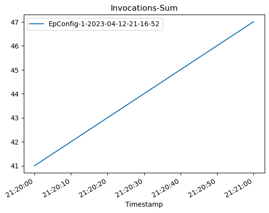

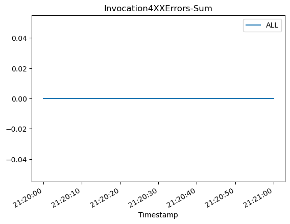

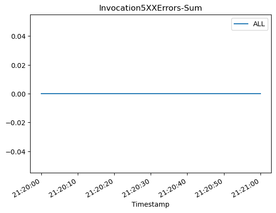

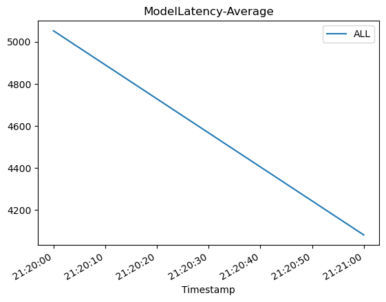

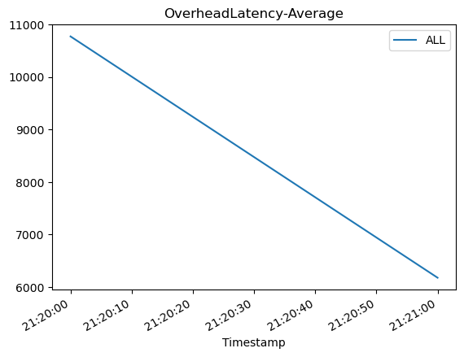

```python
invocation_metrics = plot_endpoint_invocation_metrics(
    endpoint_name, ep_config_name, "AllTraffic", "Invocations", "Sum"
)
invocation_4xx_metrics = plot_endpoint_invocation_metrics(
    endpoint_name, None, "AllTraffic", "Invocation4XXErrors", "Sum"
)
invocation_5xx_metrics = plot_endpoint_invocation_metrics(
    endpoint_name, None, "AllTraffic", "Invocation5XXErrors", "Sum"
)
model_latency_metrics = plot_endpoint_invocation_metrics(
    endpoint_name, None, "AllTraffic", "ModelLatency", "Average"
)
overhead_latency_metrics = plot_endpoint_invocation_metrics(
    endpoint_name, None, "AllTraffic", "OverheadLatency", "Average"
)
```